# Binary Outcomes

EC 325: Econometrics

Prof. Caraher

Colby College

2026-04-07

## Where We Are

- We’ve been building a regression toolkit all semester
- Started with bivariate OLS, added multiple regression, statistical inference
- Incorporated **qualitative information on the right-hand side**: dummy variables for categories, interaction effects for differential slopes
- Made our models more flexible: polynomials, logs, robust SEs

Today: what happens when the **left-hand side** — the dependent variable — is qualitative?

## Binary Outcomes Are Everywhere

| Field | Outcome | $y = 1$ | $y = 0$ |
| --- | --- | --- | --- |
| Labor | Employed? | Working | Not working |
| Health | Low birthweight? | < 2,500g | $\geq$ 2,500g |
| Education | Graduated? | Yes | No |
| Finance | Defaulted? | Yes | No |
| Policy | Enrolled in program? | Yes | No |

These are all **binary** (or **dummy**) dependent variables: $y$ can only be 0 or 1.

## The Key Insight (1/2)

When $y$ is 0 or 1, what does $E(y \mid \mathbf{x})$ mean?

Recall the formula for expected value. When $y$ takes only two values:

$$E(y \mid \mathbf{x}) = \sum_{\text{all values}} [\text{value} \times P(\text{value})]$$

$$= 1 \times P(y = 1 \mid \mathbf{x}) \;+\; 0 \times P(y = 0 \mid \mathbf{x})$$

$$= P(y = 1 \mid \mathbf{x})$$

## The Key Insight (2/2)

So we have:

$$E(y \mid \mathbf{x}) = P(y = 1 \mid \mathbf{x})$$

Why does this matter? Recall that OLS estimates the conditional expectation $E(y \mid \mathbf{x})$.

So when $y$ is binary, OLS is estimating a **probability**.

With a binary dependent variable, $\hat{y}$ is the **predicted probability** that $y = 1$, given the values of $\mathbf{x}$.

## The Linear Probability Model

Just run OLS with a binary $y$:

$$y = \beta_0 + \beta_1 x_1 + \beta_2 x_2 + \cdots + \beta_k x_k + \mu$$

This is called the **linear probability model** (LPM).

Since $\hat{y} = \hat{P}(y = 1 \mid \mathbf{x})$, the coefficients have a special interpretation:

$\hat{\beta}_j$ = the change in the **probability** of $y = 1$ for a one-unit increase in $x_j$, holding all else constant.

## Interpretation: Percentage Points!

**Be Careful with Language**

If $\hat{\beta}_1 = -0.15$, we say:

“A one-unit increase in $x_1$ **decreases the probability** of $y = 1$ by **15 percentage points**.”

**Not** “15 percent”! Percentage points and percent are different things.

- Suppose $P(y = 1) = 0.60$ and $\hat{\beta}_1 = -0.15$:
  - New probability: $0.60 - 0.15 = 0.45$
  - That’s a 15 **percentage point** decrease
  - But it’s a 25 **percent** decrease (since $0.15 / 0.60 = 0.25$)

## Example: Women’s Labor Force Participation

The `mroz` dataset from `wooldridge`: **753 married women** in 1975.

- `inlf` = 1 if in the labor force, 0 otherwise
- `kidslt6` = number of children under age 6
- `kidsge6` = number of children aged 6–18
- `nwifeinc` = husband’s income (thousands of $)
- `educ` = woman’s years of education

**Question:** what factors affect whether a married woman participates in the labor force?

## The Raw Data

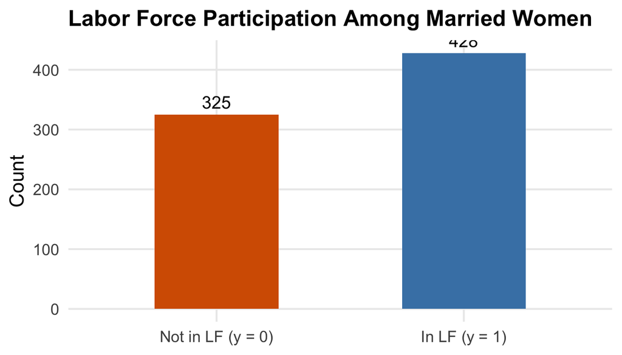

Figure 1

About 57% of women in the sample are in the labor force. Unlike continuous outcomes, there are no in-between values.

## Raw Relationship: Young Children and LFP

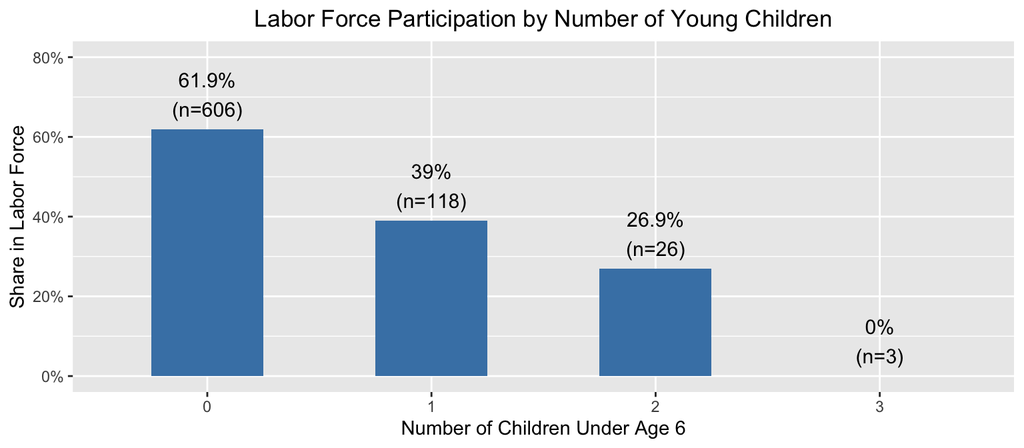

Figure 2

Clear pattern: more young children $\rightarrow$ lower LFP. Let’s see what the LPM tells us.

## Estimating the LPM

```r
reg_lpm <- lm(inlf ~ kidslt6 + kidsge6 + nwifeinc + educ,
              data = lf_data)
summary(reg_lpm)
```

```
Call:
lm(formula = inlf ~ kidslt6 + kidsge6 + nwifeinc + educ, data = lf_data)

Residuals:
    Min      1Q  Median      3Q     Max
-0.8736 -0.4916  0.2178  0.3815  0.9348

Coefficients:
             Estimate Std. Error t value          Pr(>|t|)
(Intercept)  0.048495   0.095947   0.505             0.613
kidslt6     -0.225979   0.032730  -6.904 0.000000000010777 ***
kidsge6      0.014238   0.012950   1.099             0.272
nwifeinc    -0.007811   0.001520  -5.138 0.000000354207197 ***
educ         0.057914   0.007814   7.412 0.000000000000338 ***
---
Signif. codes:  0 '***' 0.001 '**' 0.01 '*' 0.05 '.' 0.1 ' ' 1

Residual standard error: 0.4655 on 748 degrees of freedom
Multiple R-squared:  0.1225,    Adjusted R-squared:  0.1178
F-statistic: 26.09 on 4 and 748 DF,  p-value: < 0.00000000000000022
```

## Interpreting the Coefficients

### `kidsge6`: $\hat{\beta}_2 \approx 0.01$

Older children have little effect — small and not significant.

## Two Problems with the LPM

The LPM is simple and intuitive, but it has two important drawbacks:

1. **Built-in heteroskedasticity**: when $y$ is binary, the error variance *always* depends on $\mathbf{x}$, violating Gauss-Markov assumption 5. (We already know how to fix this!)
2. **Out-of-bounds predictions**: the LPM is a straight line, so it can produce predicted probabilities **less than 0** or **greater than 1** — which are impossible.

Let’s look at each one.

## Problem 1: Built-In Heteroskedasticity

When $y$ is binary, the error $\mu = y - E(y \mid \mathbf{x})$ can only take **two possible values** for a given $\mathbf{x}$:

- If $y = 1$: $\;\mu = 1 - p(\mathbf{x})$, which happens with probability $p(\mathbf{x})$
- If $y = 0$: $\;\mu = 0 - p(\mathbf{x}) = -p(\mathbf{x})$, which happens with probability $1 - p(\mathbf{x})$

where $p(\mathbf{x}) = E(y \mid \mathbf{x})$ is the predicted probability.

The variance of this error is:

$$\text{Var}(\mu \mid \mathbf{x}) = p(\mathbf{x})\big[1 - p(\mathbf{x})\big]^2 + \big[1 - p(\mathbf{x})\big]\big[p(\mathbf{x})\big]^2 = p(\mathbf{x})\big(1 - p(\mathbf{x})\big)$$

This depends on $p(\mathbf{x})$, which depends on $\mathbf{x}$. **The error variance changes with $\mathbf{x}$** — that’s heteroskedasticity, by definition!

## Visualizing LPM Heteroskedasticity

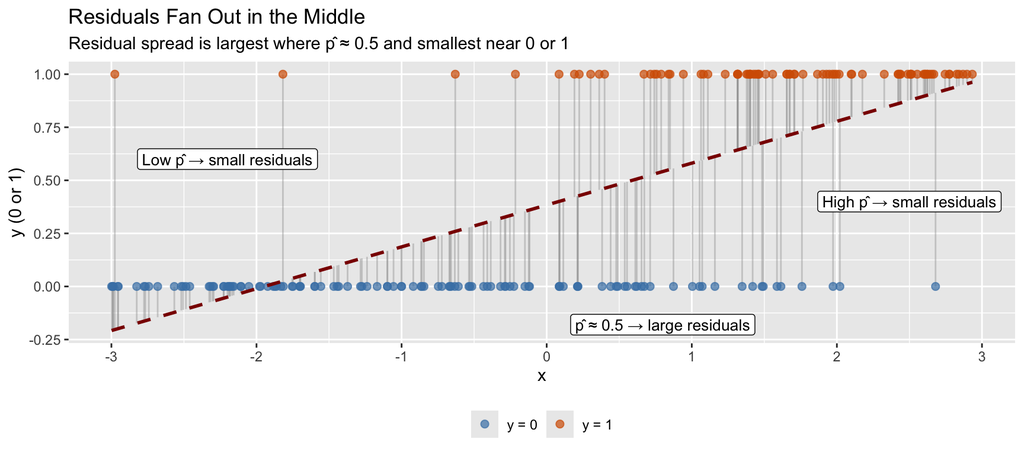

Figure 3

## The Fix: Robust Standard Errors

We already know how to handle this from our heteroskedasticity unit!

Just use `feols()` with `vcov = "HC1"`:

```r
# Standard OLS SEs (wrong under heteroskedasticity)
lpm_default <- feols(inlf ~ kidslt6 + kidsge6 + nwifeinc + educ,
                     data = lf_data)

# Robust SEs (correct)
lpm_robust <- feols(inlf ~ kidslt6 + kidsge6 + nwifeinc + educ,
                    vcov = "HC1", data = lf_data)
```

## The LPM in Practice

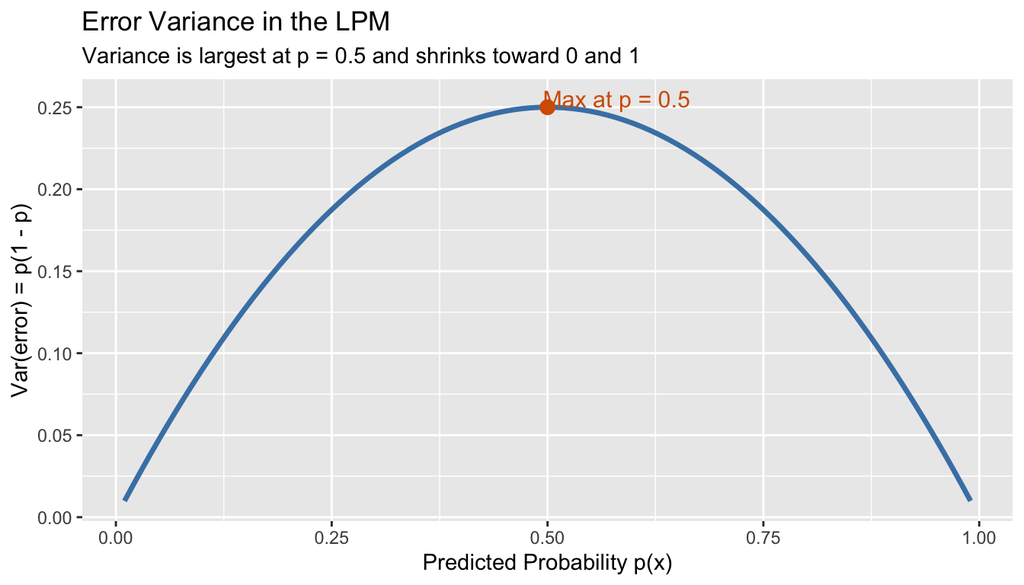

Figure 4

- Problem 1 (heteroskedasticity): ✅ solved with robust SEs
- Problem 2 (out-of-bounds): still a concern — let’s look at it now

## Problem 2: Out-of-Bounds Predictions

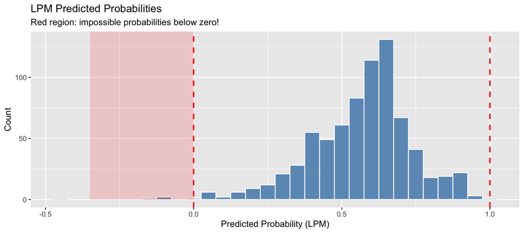

Figure 5

The LPM is a **straight line** — for extreme enough values of $\mathbf{x}$, it will cross the 0 or 1 boundary. No easy fix for this one — we need a different model.

## An Alternative: Logistic/Logit Regression

What if instead of a straight line, we used a function that **keeps predictions between 0 and 1**?

$$P(y = 1 \mid \mathbf{x}) = G(\beta_0 + \beta_1 x_1 + \cdots + \beta_k x_k)$$

where $G(z) = \frac{\exp(z)}{1 + \exp(z)}$ is the **logistic function**.

The idea: wrap the linear index $\beta_0 + \beta_1 x_1 + \cdots$ inside $G(\cdot)$, which maps any real number into the interval $(0, 1)$.

## The Logistic Function

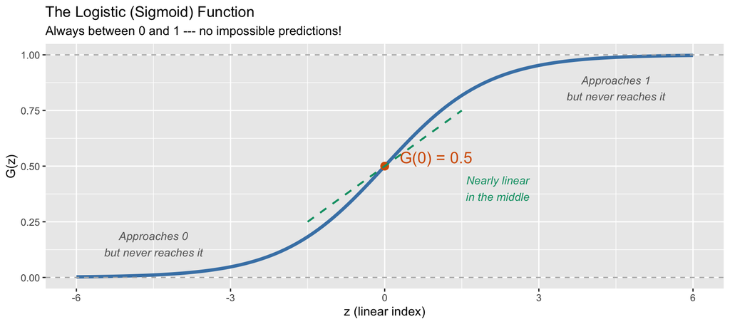

Figure 6

## Key Properties

- **Always between 0 and 1** — no out-of-bounds predictions
- **S-shaped**: nearly linear in the middle, curves at extremes
- **Symmetric** around $z = 0$ (where $G = 0.5$)

Because $G(\cdot)$ is nonlinear, we can’t use OLS. Instead: **Maximum Likelihood Estimation** (MLE).

**OLS** minimizes $\sum(y_i - \hat{y}_i)^2$.

**MLE** finds coefficients that make the observed data **most probable**: high $\hat{p}_i$ when $y_i = 1$, low $\hat{p}_i$ when $y_i = 0$.

## Estimating Logit in R

Just like switching from `lm()` to `feols()`, we use `feglm()` from `fixest`:

```r
logit_reg <- feglm(inlf ~ kidslt6 + kidsge6 + nwifeinc + educ,
                   family = binomial(link = "logit"),
                   data = lf_data)
summary(logit_reg)
```

```
GLM estimation, family = binomial(link = "logit"), Dep. Var.: inlf
Observations: 753
Standard-errors: IID
             Estimate Std. Error  z value   Pr(>|z|)
(Intercept) -2.170512   0.471698 -4.60149 4.1949e-06 ***
kidslt6     -1.086812   0.168727 -6.44125 1.1850e-10 ***
kidsge6      0.067237   0.060319  1.11470 2.6498e-01
nwifeinc    -0.038898   0.007886 -4.93224 8.1293e-07 ***
educ         0.277681   0.040353  6.88128 5.9317e-12 ***
---
Signif. codes:  0 '***' 0.001 '**' 0.01 '*' 0.05 '.' 0.1 ' ' 1
Log-Likelihood: -464.9   Adj. Pseudo R2: 0.089242
           BIC:  963.0     Squared Cor.: 0.124478
```

- The key argument is `family = binomial(link = "logit")`
- This tells `feglm()` to use the logistic formula in the regression

## Side-by-Side Comparison

```r
modelsummary(
  list("LPM" = reg_lpm,
       "Logit" = logit_reg),
  stars = c('*' = 0.1,
            '**' = 0.05,
            '***' = 0.01),
  gof_map = c("nobs",
              "r.squared",
              "logLik"))
```

|  | LPM | Logit |
| --- | --- | --- |
| (Intercept) | 0.048 | -2.171*** |
|  | (0.096) | (0.472) |
| kidslt6 | -0.226*** | -1.087*** |
|  | (0.033) | (0.169) |
| kidsge6 | 0.014 | 0.067 |
|  | (0.013) | (0.060) |
| nwifeinc | -0.008*** | -0.039*** |
|  | (0.002) | (0.008) |
| educ | 0.058*** | 0.278*** |
|  | (0.008) | (0.040) |
| Num.Obs. | 753 | 753 |
| R2 | 0.122 | 0.097 |
| Log.Lik. | -490.229 |  |

* p < 0.1, ** p < 0.05, *** p < 0.01

- **Signs** are the same across both models — they agree on directions
- But **magnitudes** differ: logit coefficients are on a **different scale** (log-odds)
- How do we interpret them?

## Interpreting Logit: The Problem

In the LPM, $\hat{\beta}_j$ is the change in **probability** — simple and direct.

In logit, $\hat{\beta}_j$ is the change in the **log-odds** — not directly intuitive.

Three ways to make sense of logit coefficients:

1. **Log-odds** (direct, but abstract)
2. **Odds ratios** (exponentiate the coefficient)
3. **Marginal effects** (most practical — directly comparable to LPM)

Let’s walk through all three.

## Interpretation 1: Log-Odds

The **odds** of an event are: $\;\text{Odds} = \frac{P(y = 1)}{1 - P(y = 1)}$

- If $P = 0.75$: odds = $0.75 / 0.25 = 3$ (“3 to 1 in favor”)
- If $P = 0.50$: odds = $0.50 / 0.50 = 1$ (“even odds”)
- If $P = 0.20$: odds = $0.20 / 0.80 = 0.25$ (“4 to 1 against”)

The logit model is linear in the **log-odds**:

$$\ln\left(\frac{P(y = 1 \mid \mathbf{x})}{1 - P(y = 1 \mid \mathbf{x})}\right) = \beta_0 + \beta_1 x_1 + \cdots + \beta_k x_k$$

So $\hat{\beta}_j$ is the change in **log-odds** for a one-unit increase in $x_j$.

This is mathematically clean, but not very intuitive — most people don’t think in log-odds. The main practical use: **positive** coefficients increase the probability; **negative** coefficients decrease it.

## Interpretation 2: Odds Ratios

Exponentiating the logit coefficient gives the **odds ratio**: $\exp(\hat{\beta}_j)$.

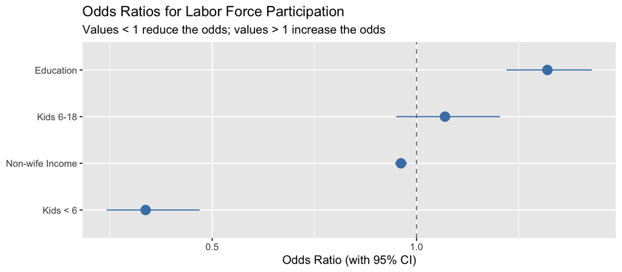

Figure 7

## Interpretation 3: Marginal Effects

Unlike the LPM, the logit’s effect on probability **depends on where you start**.

To compute the marginal effect of a variable:

1. **Pick specific values** for all the $x$ variables
2. Compute the **predicted probability** at those values
3. **Increase the variable of interest by 1**, keeping everything else the same
4. Compute the **new predicted probability**
5. **Subtract**: the difference is the marginal effect

Marginal effect = $\hat{P}(y = 1 \mid x_j + 1) \;-\; \hat{P}(y = 1 \mid x_j)$

Let’s walk through a concrete example.

## A Quick Note on `predict()`

R’s `predict()` function lets us compute $\hat{y}$ automatically for any values of $\mathbf{x}$.

Instead of manually plugging numbers into the estimated equation, we pass `predict()` a **fitted model** and a `newdata` data frame with the $x$ values we want:

```r
predict(my_model, newdata = data.frame(x1 = 5, x2 = 10), type = "response")
```

- The column names in `newdata` must **exactly match** the variable names in the model
- For logit models, `type = "response"` tells R to return a **predicted probability** (not the log-odds)
- Without `type = "response"`, `predict()` returns the raw linear index $\hat{\beta}_0 + \hat{\beta}_1 x_1 + \cdots$

## Marginal Effect: A Specific Woman

Consider a specific woman: **0 kids under 6**, 1 older kid, husband’s income $20k, 12 years of education.

What is the effect of her having **one young child**?

```r
# Step 1: Predicted probability with 0 kids under 6
prob_0kids <- predict(logit_reg, type = "response",
                      newdata = data.frame(kidslt6 = 0, kidsge6 = 1,
                                           nwifeinc = 20, educ = 12))

# Step 2: Predicted probability with 1 kid under 6 (everything else the same)
prob_1kid <- predict(logit_reg, type = "response",
                     newdata = data.frame(kidslt6 = 1, kidsge6 = 1,
                                          nwifeinc = 20, educ = 12))

cat("P(working | 0 kids < 6):", round(prob_0kids, 4), "\n")
```

```
P(working | 0 kids < 6): 0.6109
```

```r
cat("P(working | 1 kid < 6): ", round(prob_1kid, 4), "\n")
```

```
P(working | 1 kid < 6):  0.3462
```

```r
cat("Marginal effect:        ", round(prob_1kid - prob_0kids, 4), "\n")
```

```
Marginal effect:         -0.2647
```

For this particular woman, one young child decreases the probability of working by about **26 percentage points**.

## A Different Woman, A Different ME

Now consider a woman with the same characteristics but **husband’s income of $50k**:

```r
prob_0kids_rich <- predict(logit_reg, type = "response",
                           newdata = data.frame(kidslt6 = 0, kidsge6 = 1,
                                                nwifeinc = 50, educ = 12))
prob_1kid_rich <- predict(logit_reg, type = "response",
                          newdata = data.frame(kidslt6 = 1, kidsge6 = 1,
                                               nwifeinc = 50, educ = 12))

cat("P(working | 0 kids < 6):", round(prob_0kids_rich, 4), "\n")
```

```
P(working | 0 kids < 6): 0.3283
```

```r
cat("P(working | 1 kid < 6): ", round(prob_1kid_rich, 4), "\n")
```

```
P(working | 1 kid < 6):  0.1415
```

```r
cat("Marginal effect:        ", round(prob_1kid_rich - prob_0kids_rich, 4), "\n")
```

```
Marginal effect:         -0.1868
```

- The marginal effect is **different** because this woman starts at a different predicted probability.
- Just like all non-linear models, the ME depends on the values of $x_j$

## Marginal Effect at the Mean

- How do we know which $x$ values to report ME at?
- The standard approach: evaluate at the **mean** of all explanatory variables.

```r
# Compute means of each variable
mean_data <- lf_data |>
    summarize(kidslt6 = mean(kidslt6), kidsge6 = mean(kidsge6),
              nwifeinc = mean(nwifeinc), educ = mean(educ))
mean_data
```

```
    kidslt6  kidsge6 nwifeinc     educ
1 0.2377158 1.353254 20.12896 12.28685
```

```r
# Probability at the mean
prob_at_mean <- predict(logit_reg, type = "response", newdata = mean_data)

# Probability with one more kid under 6
mean_data_plus1 <- mean_data |> mutate(kidslt6 = kidslt6 + 1)
prob_plus1 <- predict(logit_reg, type = "response", newdata = mean_data_plus1)

marginal_effect <- prob_plus1 - prob_at_mean
cat("Marginal effect at the mean:", round(marginal_effect, 4), "\n")
```

```
Marginal effect at the mean: -0.2613
```

## How Does the Logit ME Compare to the LPM?

```r
cat("Logit ME at mean:", round(marginal_effect, 4), "\n")
```

```
Logit ME at mean: -0.2613
```

```r
cat("LPM coefficient:  ", round(coef(reg_lpm)["kidslt6"], 4), "\n")
```

```
LPM coefficient:   -0.226
```

They’re **very similar**!

This is not a coincidence. Look back at the logistic function: it is nearly **linear** in the middle of its range. For observations near $p = 0.5$, the straight line (LPM) and the S-curve (logit) give approximately the same slope.

Near the center of the probability distribution, the LPM and logit produce **similar marginal effects**. They diverge mainly at the tails.

## LPM vs. Logit: Predictions Compared

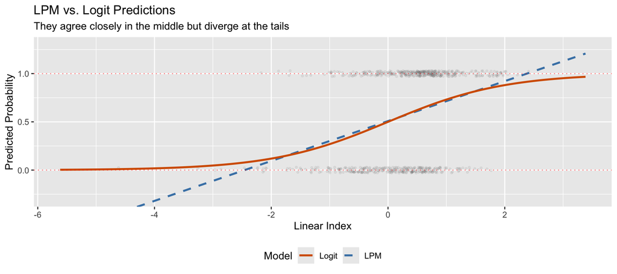

Figure 8

## Rounding Up: LPM vs. Logit

### Linear Probability Model

- Models probability as a **straight line**: $P(y = 1) = \mathbf{x}\boldsymbol{\beta}$
- Estimated by **OLS**
- Coefficients = direct change in probability
- Can predict outside [0, 1]
- Always heteroskedastic (use robust SEs)

### Logistic Regression

- Models probability through the **S-curve**: $P(y = 1) = G(\mathbf{x}\boldsymbol{\beta})$
- Estimated by **MLE**
- Coefficients = change in log-odds (convert via OR or ME)
- Predictions always in (0, 1)
- Heteroskedasticity handled by design

**The punchline:** despite these differences, the two models typically produce **very similar estimated effects** across most of the distribution of $\mathbf{x}$. They only diverge meaningfully at the tails, where predicted probabilities are near 0 or 1. For the vast majority of observations in a typical dataset, you will get essentially the same answer from either approach.

## Practical Advice

For causal analysis…

- **In economics**: the LPM is the workhorse. Most applied micro papers use it as the primary specification, sometimes reporting logit as a robustness check.
- **In health sciences/comp sci/other fields**: logistic regression is the standard. Odds ratios are commonly references lingua franca.

But for Prediction…

- logit wins across fields — its predictions are always valid probabilities.

## When to Use Which?

|  | LPM | Logistic Regression |
| --- | --- | --- |
| **Estimation** | OLS | Maximum Likelihood |
| **Coefficients** | Change in probability | Change in log-odds |
| **Interpretation** | Direct and intuitive | Requires conversion (OR or ME) |
| **Predictions** | Can fall outside [0, 1] | Always in (0, 1) |
| **Heteroskedasticity** | Always present (use robust SEs) | Handled by MLE |
| **Common in** | Economics | Health sciences, epidemiology |
| **Best for** | Causal inference | Prediction |

## Summary

1. When $y$ is binary, $E(y \mid \mathbf{x}) = P(y = 1 \mid \mathbf{x})$
2. **LPM**: run OLS; $\hat{\beta}_j$ = change in probability (percentage points)
3. LPM problems: out-of-bounds predictions and always heteroskedastic (use robust SEs!)
4. **Logit**: wraps predictions in the logistic function; estimated by MLE
5. Logit coefficients = log-odds; convert via odds ratios or marginal effects
6. **Marginal effects at the mean** are the most practical way to compare logit to LPM
7. Near the center of the distribution, the two models typically **agree closely**

# Try It Yourself

## Try It Yourself: Setup

The `bwght` dataset in `wooldridge` has data on infant birthweight. Create a binary variable `low_bwght` equal to 1 if `bwght < 88` (below 2,500 grams).

```r
bw_data <- wooldridge::bwght |>
  mutate(low_bwght = ifelse(bwght < 88, 1, 0))
```

- We’ll use this dataset for the next three questions.

## Question 1: Estimate Two Models

Estimate an LPM (with robust SEs) and a logit model of the form:

$$low\_bwght = \beta_0 + \beta_1 \cdot cigs + \beta_2 \cdot faminc + \beta_3 \cdot motheduc + \mu$$

```r
lpm_bw  <- feols(low_bwght ~ cigs + faminc + motheduc,
                 vcov = "HC1", data = bw_data)

logit_bw <- feglm(low_bwght ~ cigs + faminc + motheduc,
                  family = binomial(link = "logit"), data = bw_data)
```

## Question 2: Interpret the LPM

Interpret the LPM coefficient on `cigs` in a sentence.

```r
summary(lpm_bw)
```

```
OLS estimation, Dep. Var.: low_bwght
Observations: 1,387
Standard-errors: Heteroskedasticity-robust
             Estimate Std. Error   t value Pr(>|t|)
(Intercept)  0.061970   0.037020  1.673934 0.094370 .
cigs         0.002576   0.001430  1.801047 0.071913 .
faminc      -0.000500   0.000376 -1.330709 0.183504
motheduc     0.000543   0.002980  0.182140 0.855500
---
Signif. codes:  0 '***' 0.001 '**' 0.01 '*' 0.05 '.' 0.1 ' ' 1
RMSE: 0.23644   Adj. R2: 0.004185
```

**Answer (template):**

> “Holding family income and mother’s education constant, smoking one additional cigarette per day during pregnancy is associated with a $0.3$ percentage-point change in the probability that the infant is born with low birthweight.”
- Remember: in the LPM, coefficients are interpreted in **percentage points** of probability.

## Question 3: Marginal Effect from Logit

Using `predict()`, compute the marginal effect of 1 additional cigarette for a woman at the **mean of all variables** using the logistic regression estimates. How does it compare to the LPM coefficient?

```r
# Average woman in the sample
avg_woman <- bw_data |>
  summarize(cigs = mean(cigs, na.rm = TRUE),
            faminc = mean(faminc, na.rm = TRUE),
            motheduc = mean(motheduc, na.rm = TRUE))

# Predicted probability at the mean, and at +1 cigarette
p0 <- predict(logit_bw, newdata = avg_woman)
p1 <- predict(logit_bw, newdata = avg_woman |> mutate(cigs = cigs + 1))

# Marginal effect of one more cigarette at the mean
p1 - p0
```

```
[1] 0.001756732
```